# Assignment 2 INFO-659

## A.2. Demographic Variables

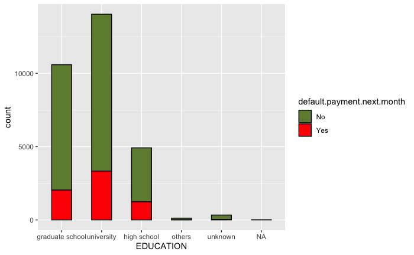

From this we can see that most of the data that we have is from population who have an university level education. With most of the people not having a default status next month.

#### Plotting sex against frequency for default

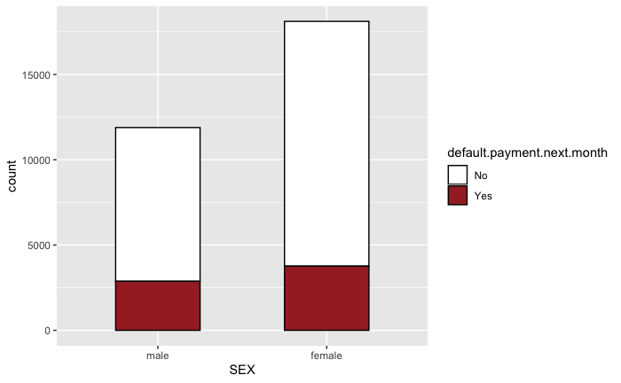

This graph shows us that we have more data for the female populus. Also,maximum female population has no Default payment for the next month.

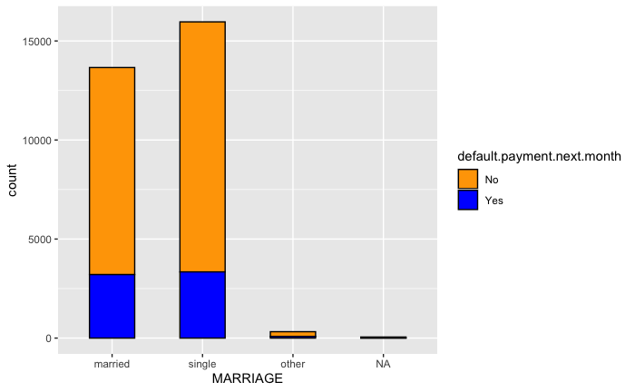

Now plotting around the age,

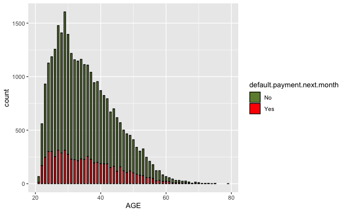

Here we can see a skewed binomial distribution. We can probably change it to a bell curve by a log transformation.

Here we can see that bell curve for The defaulters and total population distributed by the age, have somewhat same skewed nature. Thus we can draw the assumption, That most of the defaulters came from the age of 22 to 45 and then declined steadily.

Also there must be some correlation between the Yeses for defaulters in next month and age

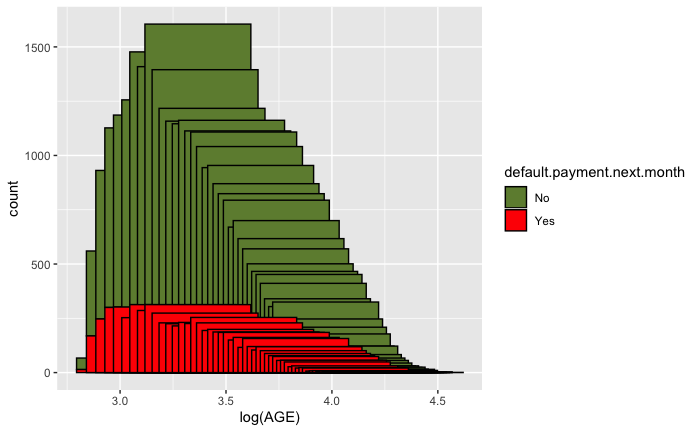

As we did not have a varied data in the age section, Log transformation didn’t perform quite well.

## A.3. Payment Status Variables

Now to plot for PAY_0, PAY_1, PAY_2, PAY,3, PAY_4, PAY_5 and PAY_6

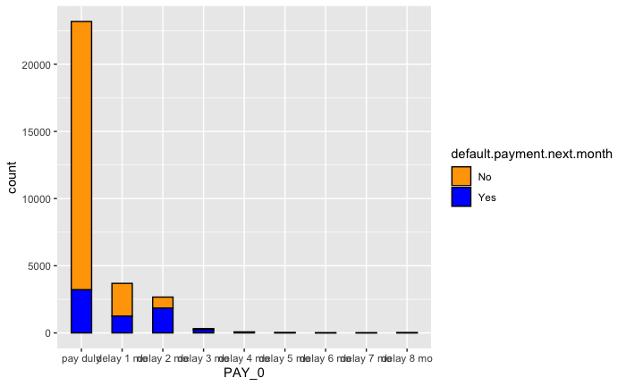

Here most of our data is concentrated for people who duly pay(largest chunk of data) with some data in for people who are late by one, two and three months. Although we can still see that people who have duly paid the bills have yes as defaulters for the next month.

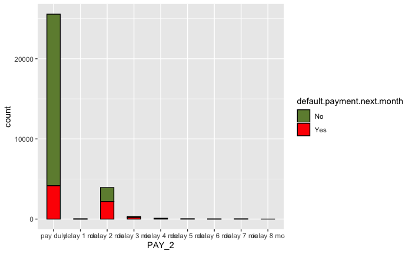

Here most of the populus has paid their installments duly, but there is some data for people who have delayed their payment by two months.

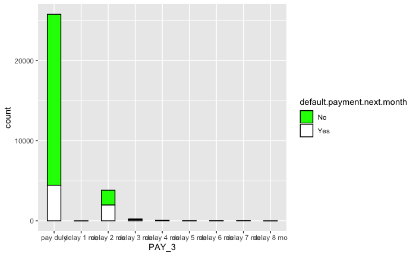

Just like PAY_2, Here most of the populus has paid their installments duly, but there is some data for people who have delayed their payment by two months.

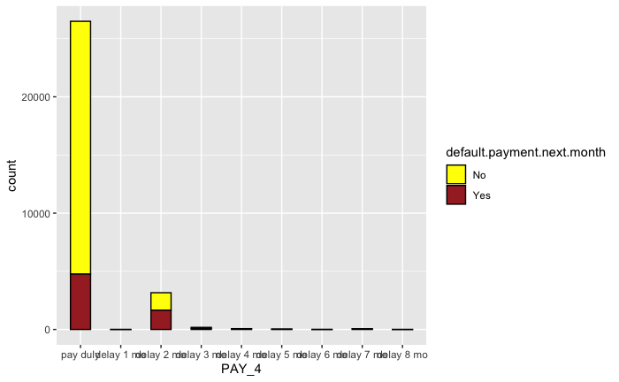

Just like PAY_2 and PAY_3, Here most of the populus has paid their installments duly, but there is some data for people who have delayed their payment by two months.

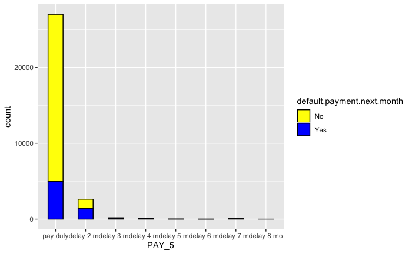

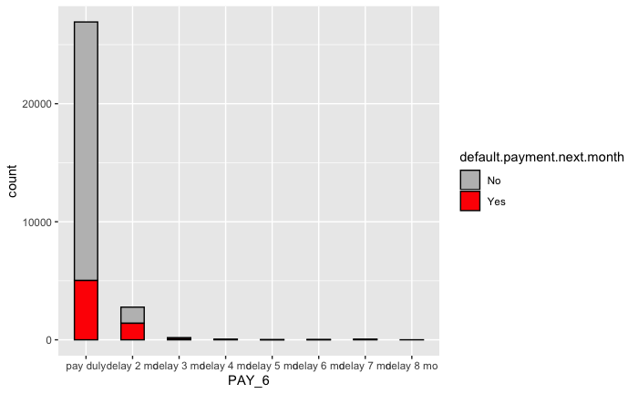

### hypthesis formulation

From the above data we can say that we can predict the defaulters in next month can be predicted using classification algorithms using attributes such as age(because of the correlation sobserved in the graph), sex, Education, marriage and the Payment features.

This can be a good business solution if one can predict which of the users are going to default in the upcoming month so that the company can target such customers and take some preventive measures.

# B. Data Classification

## B.1. Naive Bayes using Demographic Variables

```r
nbDem
```

```
Naive Bayes Classifier for Discrete Predictors

Call:
naiveBayes.default(x = X, y = Y, laplace = laplace)

A-priori probabilities:
Y
   No   Yes
0.783 0.217

Conditional probabilities:
     SEX
Y          male    female
  No  0.3971903 0.6028097
  Yes 0.4304147 0.5695853

     EDUCATION
Y     graduate school  university high school      others     unknown
  No      0.362544711 0.462698007 0.154062340 0.006642821 0.014052121
  Yes     0.332718894 0.484792627 0.176958525 0.000921659 0.004608295

     MARRIAGE
Y        married     single      other
  No  0.44336238 0.54356740 0.01307022
  Yes 0.48847926 0.49493088 0.01658986
```

Running our trained model on testing data set

```r
predict(nbDem, test[0,])
```

```
factor(0)
Levels: No Yes
```

```r
predict(nbDem, test[2,])
```

```
[1] No
Levels: No Yes
```

## B.2. Naive Bayes using Payment Status

```r
nbDem
```

```
Naive Bayes Classifier for Discrete Predictors

Call:
naiveBayes.default(x = X, y = Y, laplace = laplace)

A-priori probabilities:
Y
   No   Yes
0.783 0.217

Conditional probabilities:
     PAY_0
Y         pay duly   delay 1 mo   delay 2 mo   delay 3 mo   delay 4 mo   delay 5 mo   delay 6 mo   delay 7 mo
  No  0.8633461047 0.0993614304 0.0329501916 0.0030651341 0.0002554278 0.0005108557 0.0000000000 0.0000000000
  Yes 0.4857142857 0.2064516129 0.2580645161 0.0377880184 0.0064516129 0.0046082949 0.0000000000 0.0009216590
     PAY_0
Y       delay 8 mo
  No  0.0005108557
  Yes 0.0000000000

     PAY_2
Y         pay duly   delay 1 mo   delay 2 mo   delay 3 mo   delay 4 mo   delay 5 mo   delay 6 mo   delay 7 mo
  No  0.9261813538 0.0012771392 0.0646232439 0.0051085568 0.0020434227 0.0002554278 0.0000000000 0.0005108557
  Yes 0.6147465438 0.0000000000 0.3400921659 0.0368663594 0.0064516129 0.0000000000 0.0018433180 0.0000000000
     PAY_2
Y       delay 8 mo
  No  0.0000000000
  Yes 0.0000000000

     PAY_3
Y         pay duly   delay 1 mo   delay 2 mo   delay 3 mo   delay 4 mo   delay 5 mo   delay 6 mo   delay 7 mo
  No  0.9228607918 0.0002554278 0.0699872286 0.0043422733 0.0015325670 0.0005108557 0.0005108557 0.0000000000
  Yes 0.6580645161 0.0000000000 0.3078341014 0.0211981567 0.0055299539 0.0018433180 0.0009216590 0.0046082949
     PAY_3
Y       delay 8 mo
  No  0.0000000000
  Yes 0.0000000000

     PAY_4
Y         pay duly   delay 1 mo   delay 2 mo   delay 3 mo   delay 4 mo   delay 5 mo   delay 6 mo   delay 7 mo
```

[output cut: 9 more lines]

```
  No  0.9540229885 0.0000000000 0.0413793103 0.0022988506 0.0012771392 0.0005108557 0.0000000000 0.0005108557
  Yes 0.7520737327 0.0000000000 0.2175115207 0.0156682028 0.0046082949 0.0000000000 0.0018433180 0.0082949309
     PAY_5
Y       delay 8 mo
  No  0.0000000000
  Yes 0.0000000000

     PAY_6
Y         pay duly   delay 1 mo   delay 2 mo   delay 3 mo   delay 4 mo   delay 5 mo   delay 6 mo   delay 7 mo
  No  0.9468710089 0.0000000000 0.0487867178 0.0025542784 0.0010217114 0.0002554278 0.0002554278 0.0002554278
  Yes 0.7640552995 0.0000000000 0.2119815668 0.0092165899 0.0046082949 0.0009216590 0.0009216590 0.0073732719
     PAY_6
Y       delay 8 mo
  No  0.0000000000
  Yes 0.0009216590
```

```r
predict(nbDem, test[1,])
```

```
[1] Yes
Levels: No Yes
```

```r
predict(nbDem, test[2,])
```

```
[1] No
Levels: No Yes
```

## B.3. Smoothed Naive Bayes using Payment Status

```r
predict(nbPay, test[1,])
```

```
[1] Yes
Levels: No Yes
```

Changing the laplace value to 1 and 2

```r
predict(nbPay, test[3,])
```

```
[1] Yes
Levels: No Yes
```

```r
predict(nbPay, test[1,])
```

```
[1] Yes
Levels: No Yes
```

# C. Classification with Decision Tree

## C.1. Basic Decision Tree

```r
predict(dtPay, test[1,])
```

```
         No       Yes
1 0.3012552 0.6987448
```

```r
predict(dtPay, test[2,])
```

```
           No       Yes
214 0.8651829 0.1348171
```

```r
predict(dtPay, test[3,])
```

```
          No       Yes
23 0.3012552 0.6987448
```

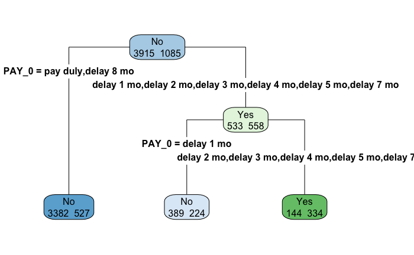

## C.2. Decision Tree with a Different Complexity Parameter

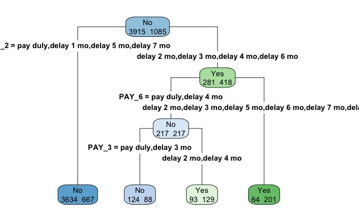

```r
predict(dtPay, test[1,])
```

```
         No       Yes
1 0.5849057 0.4150943
```

```r
predict(dtPay, test[2,])
```

```
           No       Yes
214 0.8449198 0.1550802
```

```r
predict(dtPay, test[3,])
```

```
          No       Yes
23 0.8449198 0.1550802
```

# D. Conclusion

Decision Tree although gives us a better approach on how we can know how the decision was made by the model. Apart from this decision tree told us about the probablity of yes and no for each test case, Something naive bayes failed to do.